# datacamp_TS4_AutoRegressiveModels

Helen Yezerets

February 7, 2019

## Simulate the autoregressive model

The autoregressive (AR) model is arguably the **most widely used** time series model. It shares the very familiar interpretation of a simple linear regression, but here **each observation is regressed on the previous observation**.

The AR model also **includes the white noise (WN) and random walk (RW) models** examined in earlier chapters as special cases.

The versatile **arima.sim()** function used for WN and RW can also be used to simulate data from an AR model by setting the **model =list(ar = phi), n= length of series** , in which **phi** is a slope parameter from the interval (-1, 1). We also need to specify a series length n.(example: arima.sim(model =list(ar=0.5), n = 100)

### Examples:

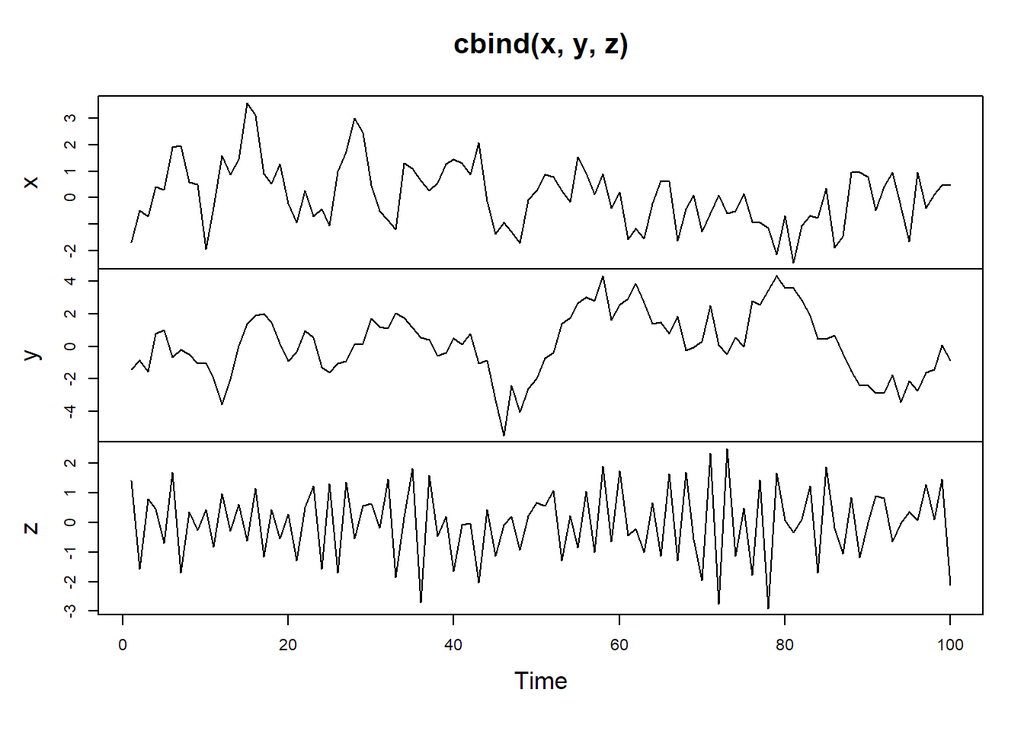

```r
# Simulate an AR model with 0.5 slope
x <- arima.sim(model =list(ar=0.5), n = 100)

# Simulate an AR model with 0.9 slope. Slope 0.9 will increase the autocorrelation
y <- arima.sim(model=list(ar=0.9), n=100)

# Simulate an AR model with -0.75 slope, negative slope will create an oscilative model
z <- arima.sim(model=list(ar=-0.75),n=100)

# Plot your simulated data
plot.ts(cbind(x, y, z))
```

### Analysis:

- x data shows a just a moderate amount of autocorrelation
- y data shows a **large amount of autocorrelation**
- z data tends to **oscillate** considerably from one observation to the next.

## Estimate the autocorrelation function (ACF) for an autoregression

The **acf()** command estimates autocorrelation by exploring lags in the data (the relationship between the current observation and lags extending backwards). **By default, this command generates a plot**.

### Examples:

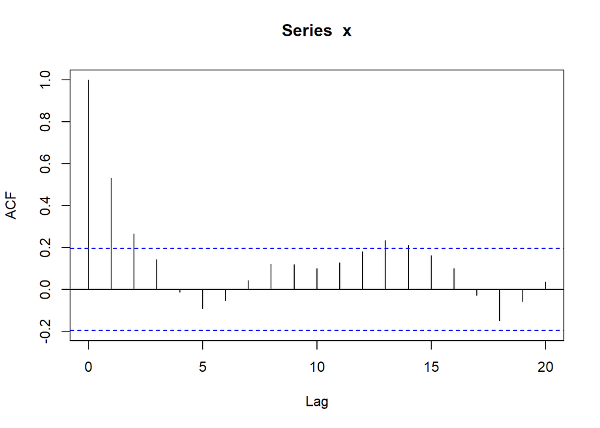

```r
# Calculate the ACF for x
acf(x)
```

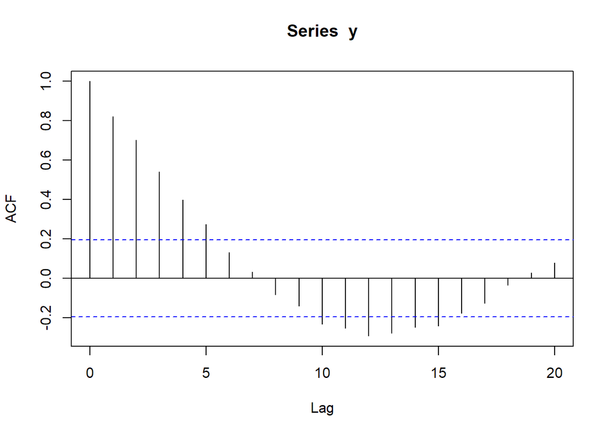

```r
# Calculate the ACF for y
acf(y)
```

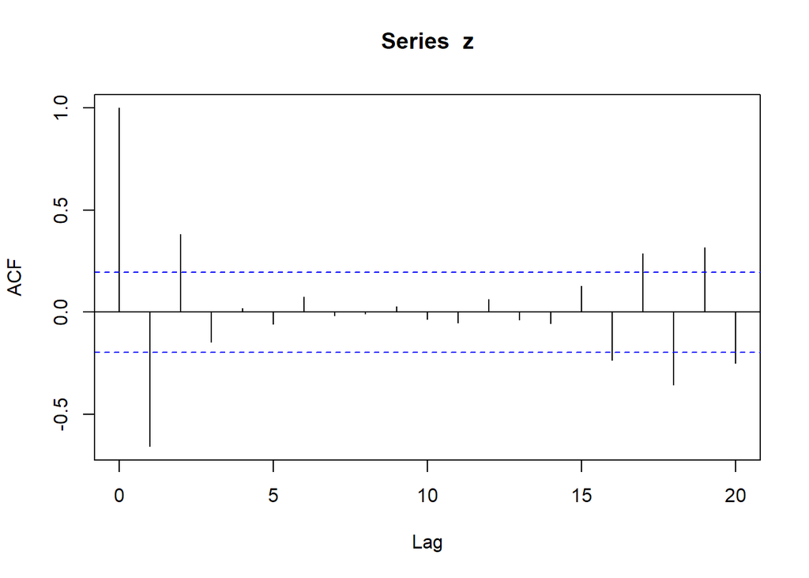

```r
# Calculate the ACF for z
acf(z)
```

### Analysis:

- The first series x has **positive autocorrelation for the first couple lags**, but they quickly approach zero.
- The second series y has **positive autocorrelation for many lags**, but they also decay to zero.
- The last series z has an **alternating pattern**, as does its autocorrelation function (ACF), but its ACF still quickly decays to zero in magnitude.

## Persistence and anti-persistence

Autoregressive processes can exhibit varying levels of persistence as well as anti-persistence or oscillatory behavior.

## Compare the random walk (RW) and autoregressive (AR) models

The random walk (RW) model is a **special case of the autoregressive (AR) model**, in which the **slope parameter is equal to 1**. The RW model is **not stationary** and exhibits **very strong persistence**. Its sample autocovariance function (ACF) also **decays to zero very slowly**, meaning past values have a **long lasting impact on current values**.

The AR model is **stationary** with a slope parameter between -1 and 1. The AR model exhibits higher persistence when its slope parameter is closer to 1, but the process **reverts to its mean** fairly quickly. Its sample ACF also decays to zero at a **quick (geometric) rate**, indicating that values far in the past have **little impact on future values** of the process.

### Examples:

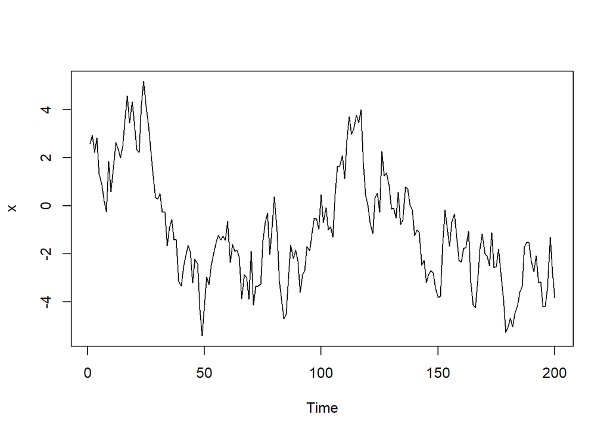

```r
# Simulate and plot AR model with slope 0.9
x <- arima.sim(model = list(ar=0.9), n = 200)
ts.plot(x)
```

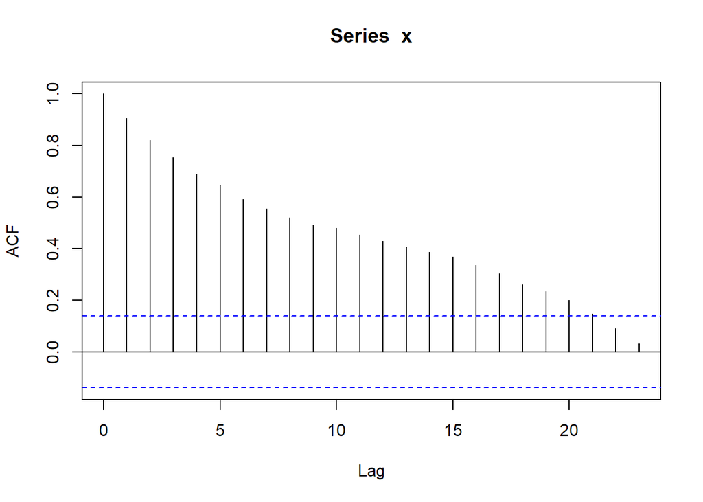

```r
acf(x)
```

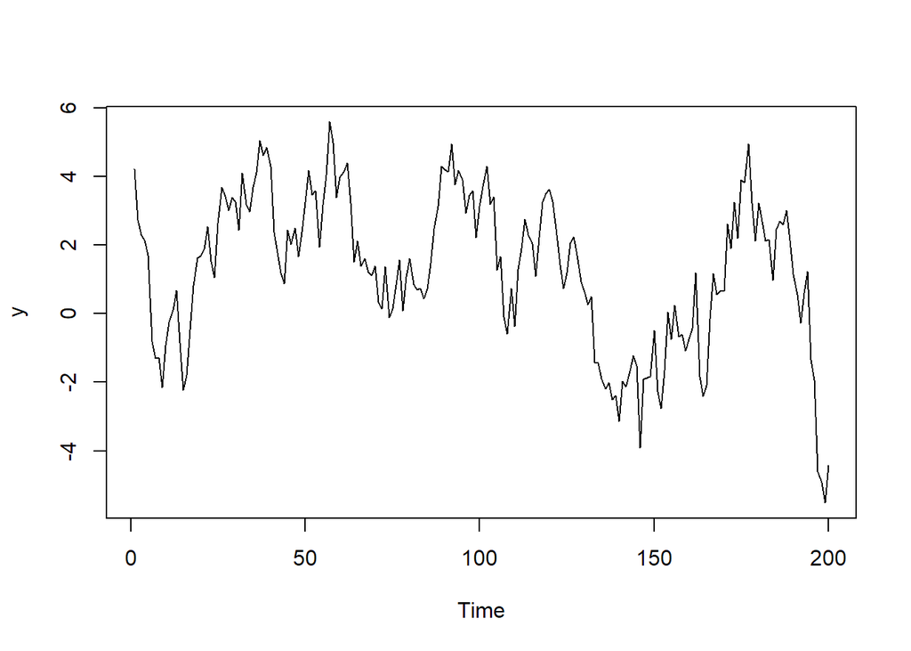

```r
# Simulate and plot AR model with slope 0.98: higher persistence when its slope parameter is closer to 1
y <- arima.sim(model= list(ar=0.98), n=200)
ts.plot(y)
```

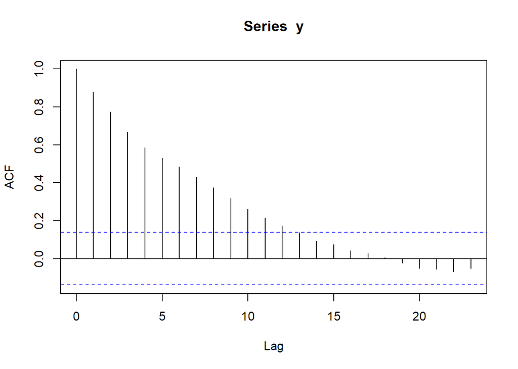

```r
acf(y)
```

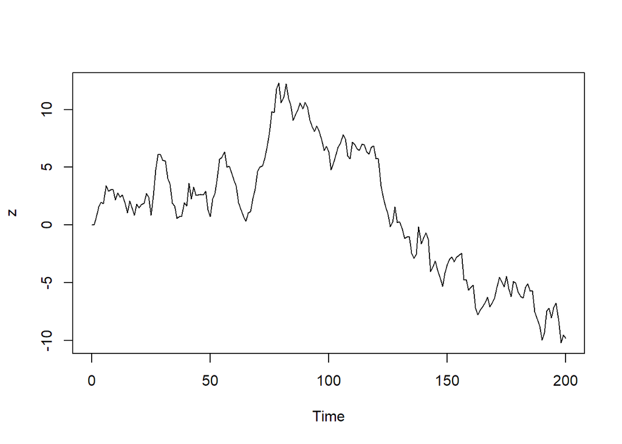

```r
# Simulate and plot RW model: slope is close to 1, strong persistence
z <- arima.sim(model= list(order=c(0,1,0)), n=200)
ts.plot(z)
```

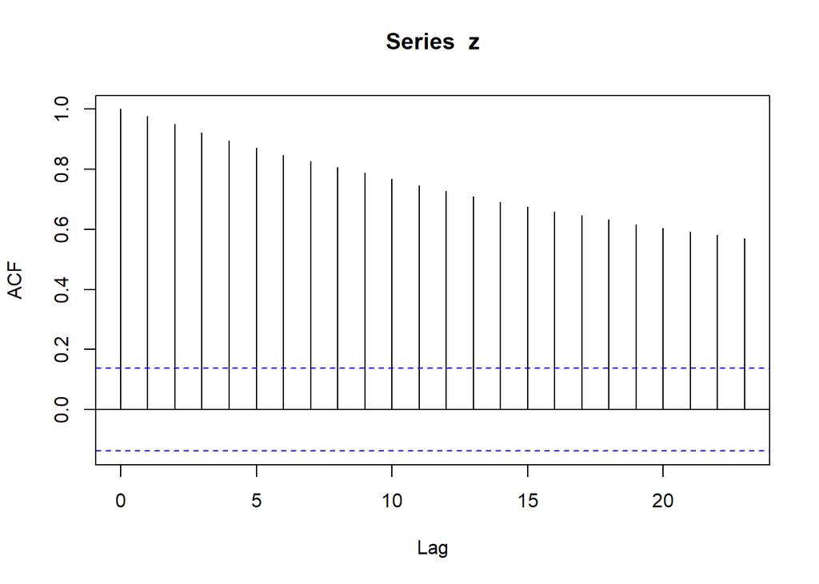

```r
acf(z)
```